title: “Case Study 1 Write Up” author: “Sam Coyne” date: “March 20, 2017” output: html_document: keep_md: true

## Introduction

This analysis details the steps performed to analyze two economic data sets published by the World Bank for the year 2012. The goal of this analysis is to determine if a given country’s GDP is a good indicator of income group. There are two data sources from the World Bank. The first data set (GDP and ranks) can be downloaded from either of these sites:

https://d396qusza40orc.cloudfront.net/getdata%2Fdata%2FGDP.csv

http://data.worldbank.org/data-catalog/GDP-ranking-table

The second data set (educational) can be downloaded from either of these sites:

https://d396qusza40orc.cloudfront.net/getdata%2Fdata%2FEDSTATS_Country.csv

http://data.worldbank.org/data-catalog/ed-stats

If replicating this study, please note both data sets need to be cleaned. Also, it should be noted, the educational data set contains many more variables than we will use in this analysis. For a complete list of variables removed, please consult with the README in the Github repository.

The data files are stored as follows: File name (GDP) getdata_data_GDP – raw data file only.

File name (Education) getdata_data_EDSTATS_Country – raw data file only

*Headers are easily located in the Education data set, but be aware the GDP will require one to skip the first five lines before reading headers.

*Both data sets are delimited by a comma (CSV) The final and tidy data set consists of the following variables:

1.) country code: a three-letter code to designate a certain country. See also: country name.

2.) ranking: a simple numerical ranking (1-190) of GDP

3.) GDP_USD_MM: a given country’s GDP (gross domestic product) measured in USD ($) MM

4.) country_name: a given country’s full name

5.) income_group: a classification variable assgined by the World Bank.

6.) geographic_region: geographic character value giving the reader more desciption if unfamiliar with country’s geography

7.) quantile: a simple rating (1-5) of GDP rank. There are 190 possible GDP ranks. As such, each quantile has 38. Every country in a certain quantile has the same quantile score.

Problems with this data set:

1.) There are some unique identifiers that are not a country. For example, “low income” has a three-letter code of LIC. Such codes may be mistaken for a country on the frist pass of an analysis. Please refer to all data cleansing steps in the README file found in the Github repository.

2.) Many variables are not complete, with many holes in observations. While such variables may have significance in other analyses, they were mostly removed from this analysis.

3.) Some countries are missing GDP values. As such, they will be excluded from this analysis. The following countries do not have a reported GDP in this data set: American Samoa (ASM), Androrra (ADO), Caymen Islands (CYM), Channel Islands (CHI), Curaco (CUW), Djibouti (DJI), Faeroe Islands (FRO), French Polynesia (PYF), Greenland (GRL), Guam (GUM), Isle of Man (IMY), Democratic People’s Republic of Korea (PRK), Libya (LBY), Liechtenstein (LIE), Myanmar (MMR), New Caledonia (NCL), Northern Mariana Islands (MNP), San Marino (SMR), Sint Maarten (SXM-Dutch Part), Somalia (SOM), St. Martin (French Part-MAF), Turks and Caicos Islands (TCA), Virgin Islands-U.S. (VIR), West Bank and Gaza (WBG).

## Glossary of Terms

GDP = Gross Domestic Product, “GDP is the monetary value of all the finished goods and services produced within a country’s borders in a specified time” (Investopedia.com/terms/g/gdp.asp)

OECD = The Organization for Economic Co-Operation and Development: “The mission…is to promote policies that will improve the economic and social well-being of people around the world” (oecd.org/about)

Raw data – The data as obtained from the World Bank. No cleaning or manipulation steps have been taken. Interested readers are encouraged to seek meaningful insight from other variables found in the raw data files. See the README for a full description of available variables.

## Folder Description

The folder ‘case_study_analysis’ contains the following:

1.) README: a thorough description of all variables in both raw and final data. More of the repetitious data cleaning aspects are also contained in this file. Also, consult this file if one would prefer a txt of the R program.

2.) raw_data: csv files from the World Bank sites.

3.) needed_packages: this R script will download ggplot2. It will be used in the visualization section of this analysis.

4.) clean_and_merge: this R script cleans the raw data files, removes superfluous variables, merges, sorts, removes any NA values, and writes a tidy CSV file to one’s working directory. See further work below for why this may be useful.

5.) main: this R script downloads the needed packages and cleans the data

5.) analysis-This R script begins completes the analysis on the combined data set. This script will complete the following analyses.

*Specifically, this script will look at differences in average ranks for OECD vs. nonOECD countries

*all visualizations

*quantile analysis based on GDP ranks

## Directions to Run the Code

```r
source("./main.R")
```

## Analysis

The mean GDP rank of High income: OECD is 32.97. Compare that to the average GDP rank of High income: nonOECD countries, 91.91. This analysis tells us that OECD membership seems to have a remarkable impact on GDP ranking (in USD MM). While there are some decent GDP rankings for countries not involved with the OECD, there appears to be a strong relationship between membership and economic performance, as measured in GDP.

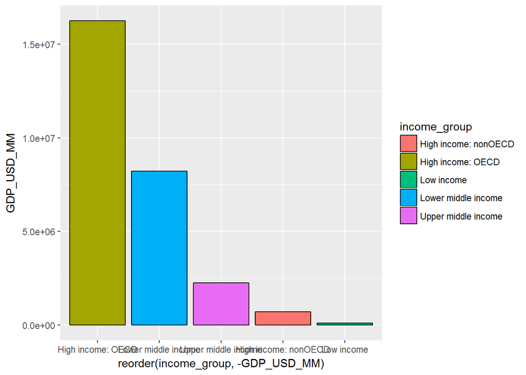

This visualization tells us the high income: OECD group far exceeds other income groups. On the other hand, having a high-income classification without OECD membership does not result in a high GDP. This suggests, but does not prove the OECD membership is the driving force behind a superb GDP figure.

## Further Work

This analysis clarifies the relationship between OECD status and gross domestic product. To expand upon this work, it is recommended one pull in additional years from the World Bank. This time series approach would reveal macroeconomic trends in OECD countries versus nonOECD countries. Another idea for additional research is to subset the raw data by geographic regions and complete “region specific” analyses. This subset approach may help answer any geographic specific questions. Suggested R packages for the above suggested analyses are zoo and ggmap. More information on those packages can be found here:

https://cran.rproject.org/web/packages/ggmap/index.html

https://cran.r-project.org/web/packages/zoo/index.html

A final tidy data set is written to the user’s working directory. This may be useful if one has access to visualization software such as Tableau and would like to graphically explore more aspects of this data set.